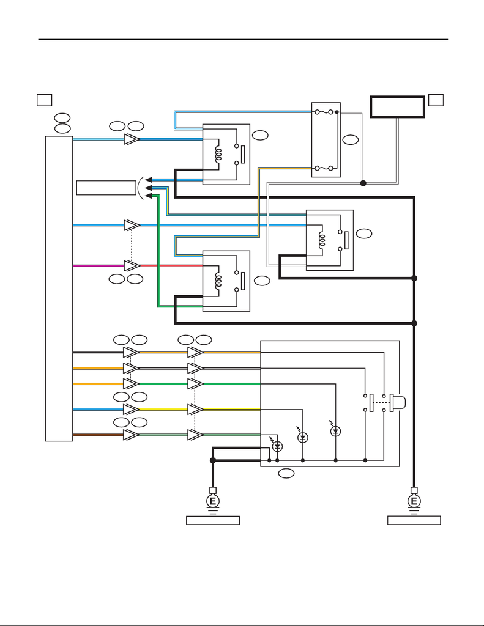

WI-329

Push Button Start System

WIRING SYSTEM

38.Push Button Start System

A: WIRING DIAGRAM

1. ENGINE TYPE FA

WI-44521

19

20

13

14

12

1a 1a

W

B553 i231

17

16

9

1

13

B576 B575

B28 B23

B576 B575

i150

B426

B23B28

15A

20A

B550

B225

B225

B575B576

B574

C:

B572

A:

3

5

11

C30 B

C28 O

A3 O

C18 L

C16 BR

2

7

12

13

11

B/O

B/W

G

Y/B

LG

B4

B5

C4 L L 1

C6 V GR/R 38

A9 SB L/R 34L/R

24W/L

23L/O

W9

L

B

B

35

B

GR/R

2

B

36G

32W/L

37L/O

4L/Y

3W

39B

33

L

B

B/O

B/W

G

Y

LG/W

B

B

MB-31

SBF-6

(B)

KEYLESS

ACCESS CM

REF. TO POWER SUPPLY

CIRCUIT [2e]

IG RELAY 2

(PUSH BUTTON START)

IG RELAY 1

(PUSH BUTTON START)

FUSE HOLDER

ACCESSORY RELAY

(PUSH BUTTON START)

ILLUMINATION

INDICATOR

(YELLOW)

INDICATOR

(GREEN)

PUSH BUTTON IGNITION SWITCH

REF. TO GND [e] REF. TO GND [b] [d]

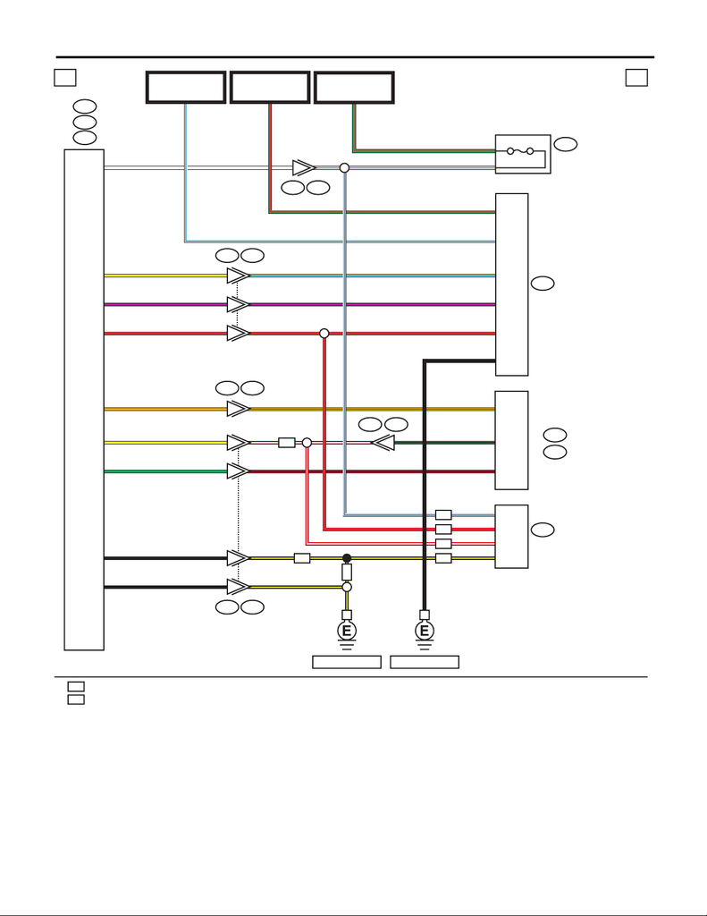

WI-330

Push Button Start System

WIRING SYSTEM

WI-44522

14

1b 1b

B424

B422

B22 E3

A:

B134

B:

E158

B575B576

B575B576

B23B28

B550

C:

B574

B:

B573

A:

B572

W/L

G/R

G/R

7

19

2

15

6

2

3

YC29

V

Y

VC26

RC17

W/L 7

B1

Y/L 3

V

Y/L

V4

R5

G/R

W GR/L

6

GR/L 25

G/R 10

OB28

YA13 Y

Y/R A2

R

Y/R

G

R

B575B576

20

12

B

R

B/YB B/YB15

2

5

R/W 4

GR/L 1

BA11 B/YB

O

GA17 R/B A4R/B

WA2

G/BG/BR/W R/W B43

ECM

B

GR/L

B/Y

R/W

ID

ND

ND

ID

ID

ID

ID

ID

ID

FB-43

F/B FUSE NO. 32

(IG)

STEERING LOCK

CM

ID CODE BOX

KEYLESS

ACCESS CM

FUSE

HOLDER

7.5A

FB-18

F/B FUSE NO. 7

(B)

REF. TO GND [d]REF. TO GND [c]

: WITHOUT ID CODE BOX

: WITH ID CODE BOX

MB-35

SBF-8

(B)

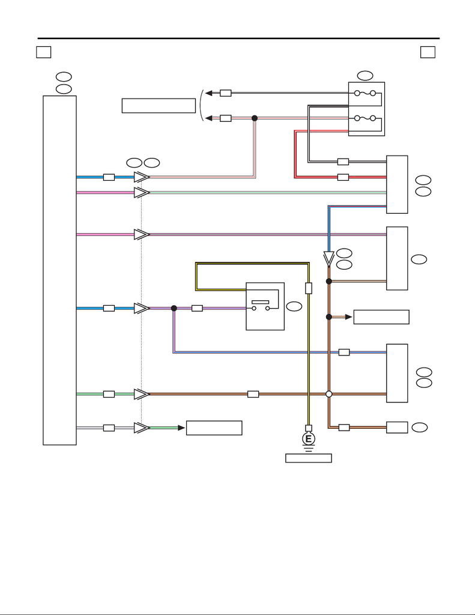

WI-331

Push Button Start System

WIRING SYSTEM

WI-44523

7

1c 1c

B116

B550

B310

B22

E3

B572A:

B574C:

P/L

B280

A:

B281

B:

B134

A:

E158

B:

10

21

4

18

LGA18

1

2

A10

B18P/L

BR/WBR/W

W/R

W/RW/R

W/B

B/W

R/W

A45

A33

A5

A7

R/W

A8

8

7

22

21

B/W

W/GW/G

L

P

L

P

5

C27 P/G P/GPP

L

LG

LC25

P/L

P/L

B/Y

B8L/R

L/RBR/W

BR/W

GR GR LGA10

BR/W

30

27

B/Y

B/Y

B54

BR/W

29

TCM

ECM

B576 B575

1

CVTCVT

CVT

MT

CVT

CVT

CVT

CVT

CVT

CVT

CVT

CVTCVT

REF. TO ENGINE ELECTRICAL

SYSTEM [2e]

REF. TO STOP LIGHT

SYSTEM [1a]

REF. TO STARTER

SYSTEM [2a]

BODY

INTEGRATED UNIT

P RANGE

SWITCH

SELECT LEVER

FUSE HOLDER

VDC CM

KEYLESS

ACCESS CM

REF. TO GND [d]

10A

10A

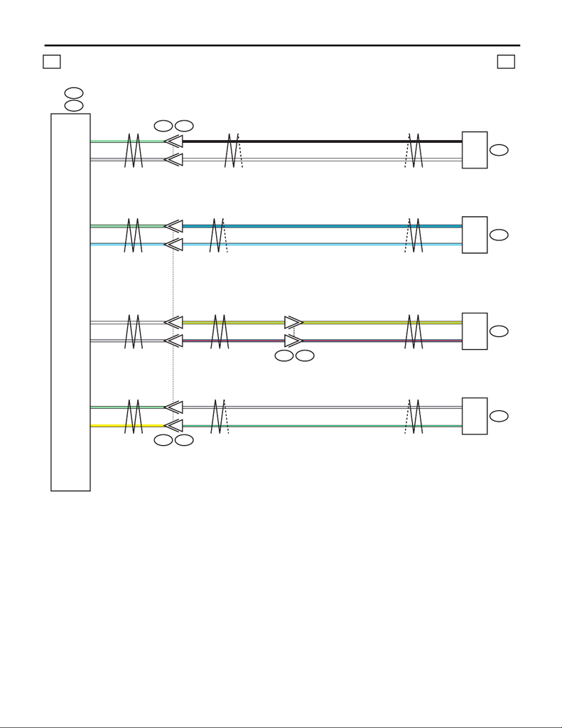

WI-332

Push Button Start System

WIRING SYSTEM

WI-44524

1d 1d

B92 R5

B579 AD11

B573B:

B574C:

R298

R299

3

8

1

6

R81 R82

7

8

AD12

R297

2

7

2

1

WB10

GRB11

W

GR

Y/L

L/R

Y/L

L/R 1

3

LG

Y

LG

Y

GR

1

2B1

B2

Y/L

L/R

Y/L

L/R

GR

GR/GGR/G

LG

SB

L/G

SB

LGC3

GR

LG

GR

B

WC2 3

1B

W

LGB8

SBB9 1

3L/G

SB

KEYLESS ACCESS

INTERIOR ANTENNA

(REAR)

KEYLESS ACCESS

INTERIOR ANTENNA

(FRONT)

KEYLESS ACCESS

EXTERIOR ANTENNA

(REAR)

KEYLESS

ACCESS CM

KEYLESS ACCESS

INTERIOR ANTENNA

(CENTER)

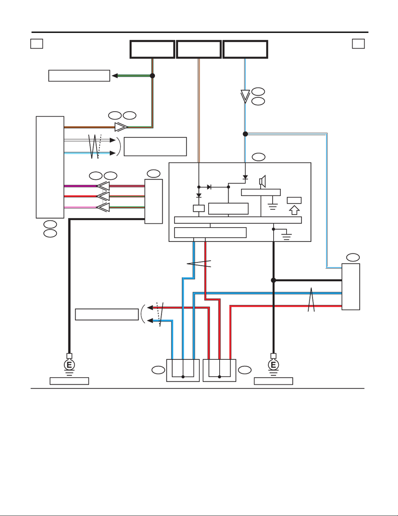

WI-333

Push Button Start System

WIRING SYSTEM

WI-44525

3

1e 1e

1

R296

i232i233

B92

i10

i229

B551

20

32

38

33R

L

L

L

R

R

B

40

C27

C35

C6

L

C1B

R

B28 B23

i84

C:

B573B:

B574C:

4

9

5

10

G/R

G/R

B

B

BR BRC5

C15

C14 W

SB

G/R

1B

5

4B5

B17

R/L

R/G

2B19 G/R

V

R

P

R5

I/F

BR/W

W/LW/L

BR/W

W/L

W/L

W/L

1

1

1

R

1

1

L

1

TFT

FB-18

F/B FUSE NO. 7

(B)

FB-12

F/B FUSE NO. 2

(IG)

MICRO COMPUTER

CAN TRANSCEIVER &

RECEIVER

POWER SUPPLY

CIRCUIT

SPEAKER

COMBINATION METER

REF. TO ENGINE ELECTRICAL

SYSTEM [2a]

REF. TO CAN COMMUNICATION

SYSTEM [b]

RECEIVER

FB-38

F/B FUSE NO. 12

(IG)

KEYLESS

ACCESS CM

BODY

INTEGRATED

UNIT

DRIVE CIRCUIT

REF. TO GND [e]REF. TO GND [f]

: TERMINAL No. OPTIONAL ARRANGEMENT

REF. TO CAN COMMUNICATION

SYSTEM [b]

J/C J/C

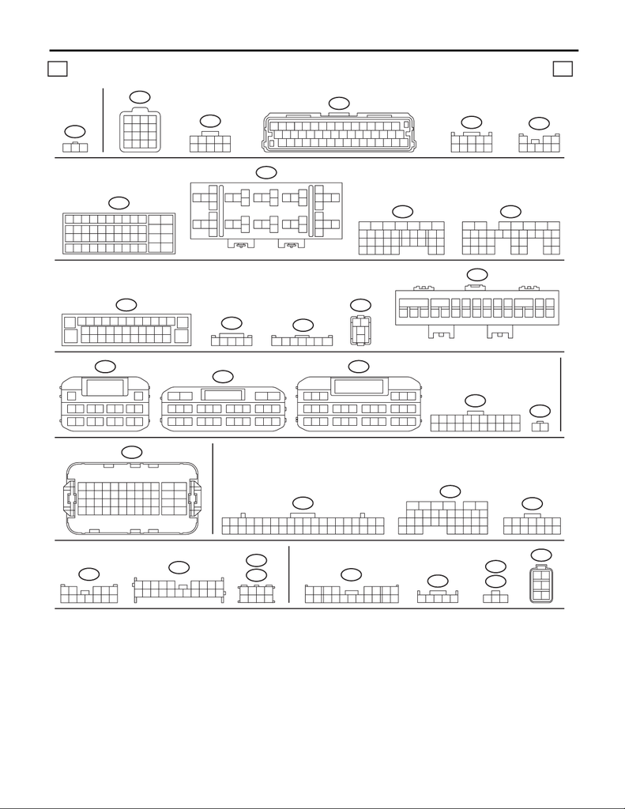

WI-334

Push Button Start System

WIRING SYSTEM

B116

123

45678

(B)

R82

1

9

234 5678

10 11 12 14 15 16 17 18 1913

WI-44526

1f 1f

i233

i232

78

5

6

34

21

i10

11 12

9

10

7856341

2

15 1613 14 19

18

20

21 22 23 24 26

25

27 28 29 30 31 32 33 34 35 36 37 38 39 40

17

B280

18

2719 20 21 22

23

26

24

25

28 29 3332 3430 31

98

15

1413121110

17

16

1234567

A:

B281B:

5672134

29

10 11 12 13 14 15

2524

16

30

98

17 18 19

20

28

21 22 23

3231

26 27

33 34 35

11 12

34

13 14

56

15 16

78

17 18

10

9

12

B572A:

i84C:

19

18

21

20

2322 24 25 26

17

1

23

4

56

27

28 29 30

31 32 33 34 35

798

151413121110 16

123

456789

10 11

12 13 14 15 16 17 18 19 20 21 22

B575

(BR)

B22

AD12

12

3

4

5678

9

10 11 12

1413 15 16

10

11 12

23 24

35 36

47 48

3

5

6

7894

12

45

4643 4441 4239 4037 38

21

2219 2017 1815 1613 14

33

3431 3229 3027 2825 26

(BR)

B134

A:

B225

10 11

12

13

14 15

16

18

19 21 22

20

17

24

5

3

17

9

8

6

32 33

34

35

28262423

25

27

29

30

31

36 37

38

40

41 43 44

42

39

B310

23456789

1

10 11 12 13

14

15

26

16 17 18 19 20 21 22 23 24 25

27 28 29 30 31 32 33 34 35 36 37

38

(B)

B426

1

2

3

4

91

2

232221 262524201918

4

13

12

17

3

16

6

15

587

14

10 11

B550

(B)

21

B579

E158

(B)

79

10

85

23

11 12

6

19 21 222017

24

35 36

47 48

18

31 33 343229 30

43 45 464441 42

3412

15 1613 14

27 2825 26

39 4037 38

B:

i229

12 345

6789

10 11 12

B23

10

12345

6789

12345

6

7

(B)

B424

i150

3

42

156

7

13 1411

12

9

10

8

i231

12345 6789

10 11 12 13 14 15 16 17 18 19 20

R296

3

421

5

R298

R297

123

B422

1

2

345

(B)

B54

123456789

10 11 12 13 14 15 16

17 18 19 20 21 22 23 24 25 26 27 28 29 30 31 32

33 34 35 36 37 38 39 40 41 42 43 44 45 46 47 48

R299

56

34

12

B92

91078

5

6

3421

123

LIST OF CONNECTORS

RELAY HOLDER

FUSE HOLDER

B573B:

17 18 19 20 21 22 23 24 25 26 27 28

567 89

10 11 12 13 14 15 16

12 34

B574C:

19 20 21 22 23 24 25 26 27 28 29 30

789

10 11 12 13 14 15 16 17 18

123 456

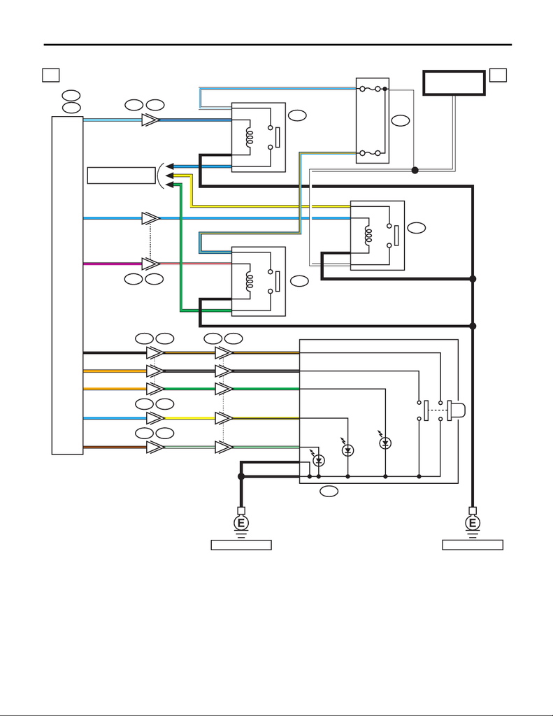

WI-335

Push Button Start System

WIRING SYSTEM

2. ENGINE TYPE EJ

WI-44527

19

20

13

14

12

2a 2a

W

B553 i231

17

16

9

1

13

B576 B575

B28 B23

B576 B575

i150

B426

B23B28

15A

20A

B550

B225

B225

B575B576

B574

C:

B572

A:

3

5

11

C30 B

C28 O

A3 O

C18 L

C16 BR

2

7

12

13

11

B/O

B/W

G

Y/B

LG

B4

B5

C4 L L 1

C6 V GR/R 38

A9 SB L/R 34L/R

25W/L

24L/O

W10

L

B

B

35

B

GR/R

2

B

36G

33W/L

37L/O

4Y

3W

39B

32

L

B

B/O

B/W

G

Y

LG/W

B

B

MB-31

SBF-6

(B)

KEYLESS

ACCESS CM

REF. TO POWER SUPPLY

CIRCUIT [4e]

IG RELAY 2

(PUSH BUTTON START)

IG RELAY 1

(PUSH BUTTON START)

FUSE HOLDER

ACCESSORY RELAY

(PUSH BUTTON START)

ILLUMINATION

INDICATOR

(YELLOW)

INDICATOR

(GREEN)

PUSH BUTTON IGNITION SWITCH

REF. TO GND [e] REF. TO GND [b] [d]

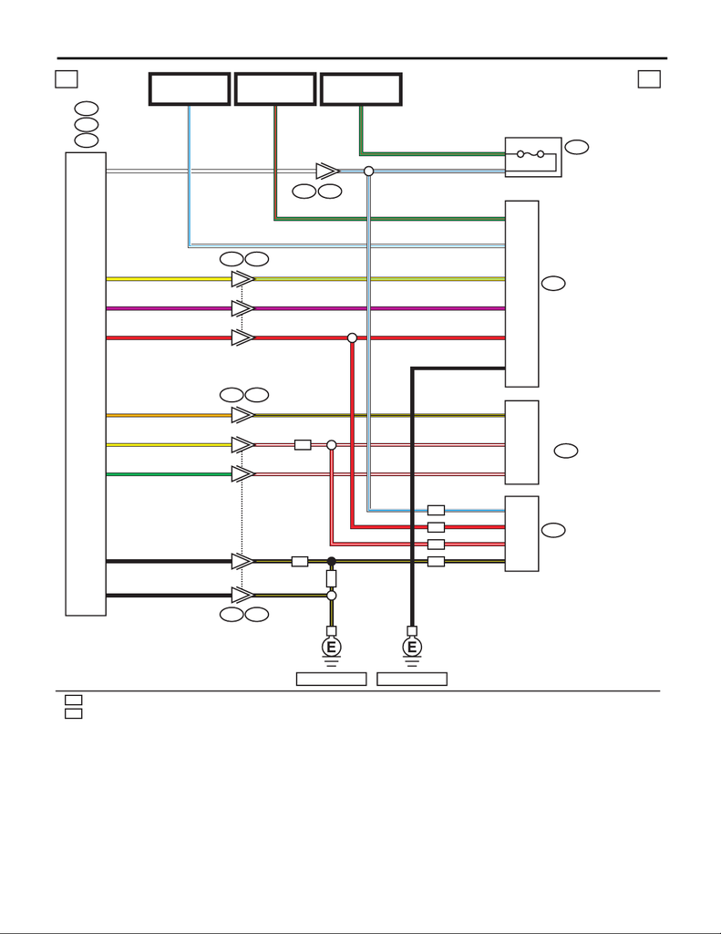

WI-336

Push Button Start System

WIRING SYSTEM

WI-44528

2b 2b

B424

B422

B:

B135

B23B28

B575B576

B575B576

B575B576

B550

C:

B574

B:

B573

A:

B572

W/L

G/R

G/R

7

19

2

15

6

2

3

YC29

V

Y

VC26

RC17

W/L 7

B1

Y/L 3

V

Y/L

V4

R5

G/R

W GR/L

6

GR/L 26

G/R 11

OB28

YA13 Y

Y/B B32

R

Y/B

G

R

O

GA17 R/W B15R/W

WA2

R/WR/W B25

20

12

BB15 B

R2

GR/L 1

BBA11 B/Y

B/YB/Y 5

R/W 4

MB-35

SBF-8

(B)

ECM

B

B/Y

ID

ND

ID

IDID

ID

ID

ID

ND

FB-43

F/B FUSE NO. 32

(IG)

STEERING LOCK

CM

ID CODE BOX

KEYLESS

ACCESS CM

FUSE

HOLDER

7.5A

FB-18

F/B FUSE NO. 7

(B)

REF. TO GND [d]REF. TO GND [c]

: WITHOUT ID CODE BOX

: WITH ID CODE BOX

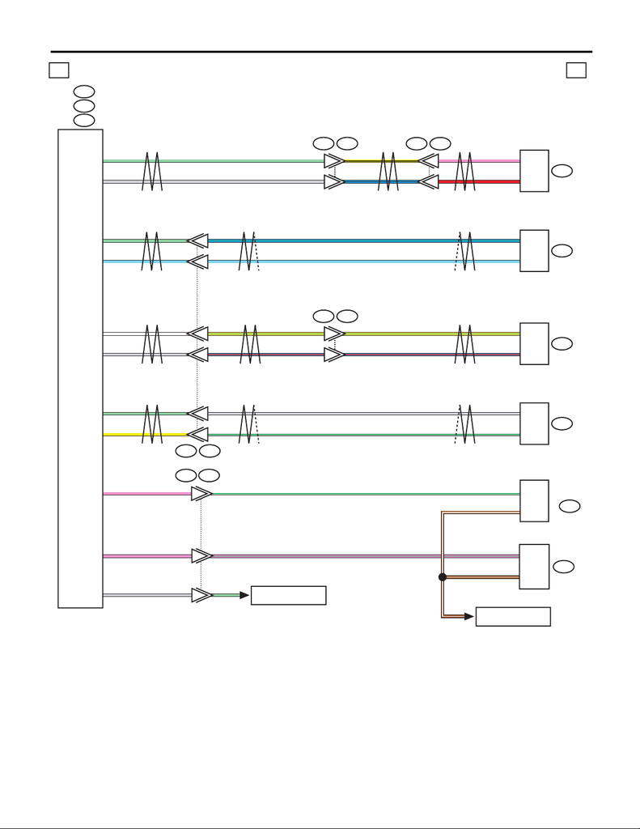

WI-337

Push Button Start System

WIRING SYSTEM

9

WI-44529

2c 2c

B92 R5

B573B:

B574C:

B572A:

R298

R299

3

8

1

6

R81 R82

7

8

B576 B575

22

8

AD12

R297

2

7

WB10

GRB11

W

GR

Y/L

L/R

Y/L

L/R 1

3

LG

Y

LG

Y

GR

1

2B1

B2

Y/L

L/R

GR

GR/GGR/G

LG

SB

L/G

SB

LGC3

GR

LG

GRC2 3

1P

R

Y/L

L/R

Y/B

L/B

LGB8

SBB9 1

3L/G

SB

B576 B575

B310

B136

C:

5

21

C16A7 W/GW/GPP

P P P/GC27

30P/G

27BR/W

C3BR/W

BR/W

ECM

VDC CM

GR GR LGA10

1

B4 AD13

3

KEYLESS ACCESS

INTERIOR ANTENNA

(REAR)

KEYLESS ACCESS

INTERIOR ANTENNA

(FRONT)

KEYLESS ACCESS

EXTERIOR ANTENNA

(REAR)

KEYLESS

ACCESS CM

KEYLESS ACCESS

INTERIOR ANTENNA

(CENTER)

REF. TO STOP LIGHT

SYSTEM [2a]

REF. TO STARTER

SYSTEM [4a]

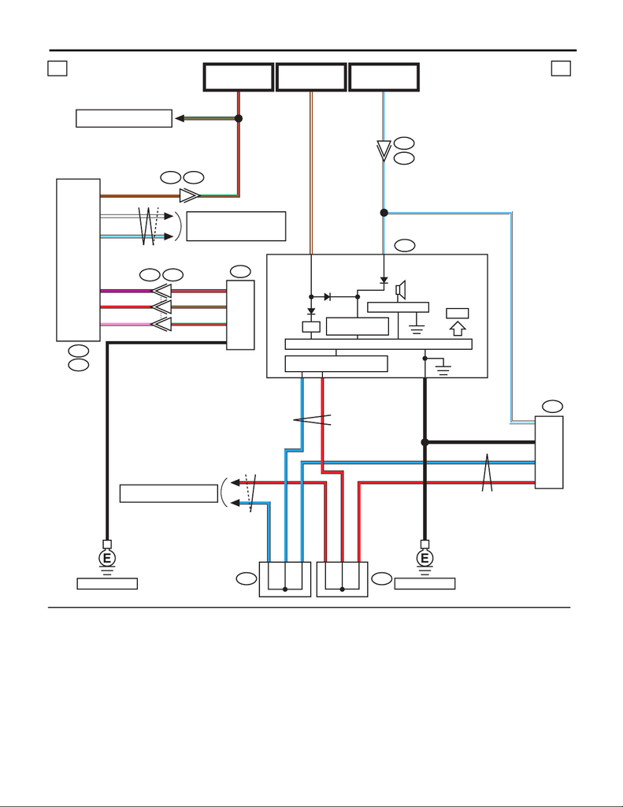

WI-338

Push Button Start System

WIRING SYSTEM

WI-44530

3

2d 2d

1

R296

B92

i10

i229

B551

20

33

32

38

R

L

B

40

C27

C35

C6

L

W/L

C1B

R

B28 B23

i84

C:

B573B:

B574C:

4

9

5

10

G/R

G/R

B

B

BR BRC5

C15

C14 W

SB

G/R

1B

5

4B5

B17

R/L

R/G

2B19 G/R

V

R

P

R5

I/F

BR/W

W/LW/L

BR/W

W/L

W/L

L

L

R

R

1

1

L

1

1

R

1

1

i232i233

TFT

FB-18

F/B FUSE NO. 7

(B)

FB-12

F/B FUSE NO. 2

(IG)

MICRO COMPUTER

CAN TRANSCEIVER &

RECEIVER

POWER SUPPLY

CIRCUIT

SPEAKER

COMBINATION METER

REF. TO ENGINE ELECTRICAL

SYSTEM [4a]

REF. TO CAN COMMUNICATION

SYSTEM [b]

RECEIVER

FB-38

F/B FUSE NO. 12

(IG)

KEYLESS

ACCESS CM

BODY

INTEGRATED

UNIT

DRIVE CIRCUIT

REF. TO GND [e]REF. TO GND [f]

: TERMINAL No. OPTIONAL ARRANGEMENT

REF. TO CAN COMMUNICATION

SYSTEM [b]

J/C J/C

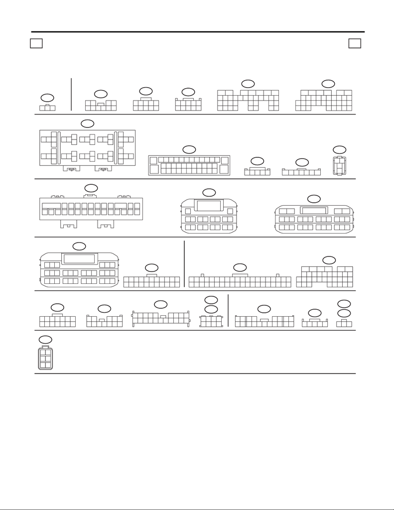

WI-339

Push Button Start System

WIRING SYSTEM

WI-44531

2e 2e

i233

i232

78

5

6

34

21

i10

11 12

9

10

7856341

2

15 1613 14 19

18

20

21 22 23 24 26

25

27 28 29 30 31 32 33 34 35 36 37 38 39 40

17

11 12

34

13 14

56

15 16

78

17 18

10

9

12

B572A:

i84C:

19

18

21

20

2322 24 25 26

17

1

23

4

56

27

28 29 30

31 32 33 34 35

798

151413121110 16

123

456789

10 11

12 13 14 15 16 17 18 19 20 21 22

B575

B225

10 11

12

13

14 15

16

18

19 21 22

20

17

24

5

3

17

9

8

6

32 33

34

35

28262423

25

27

29

30

31

36 37

38

40

41 43 44

42

39

B310

234

56789

1

10 11 12 13

14

15

26

16 17 18

19 20 21 22 23

24 25

27

28 29 30 31 32

33 34 35 36 37

38

(B)

B426

1

2

3

4

i229

12 345

6789

10 11 12

B23

10

12345

6789

1 2345

6

7

(B)

B424

i150

3

42

156

7

13 1411

12

9

10

8

i231

12345 6789

10 11 12 13 14 15 16 17 18 19 20

R296

3

421

5

R298

R297

123

B422

1

2

345

B92

91078

5

6

3421

101

242322 272625212019

5

14

13

18

432

17

7

16

698

15

11 12

B550

(B)

B135B:

5672134

29

10 11 12 13 14 15

2524

16

30

98

17 18 19

20

28

21 22 23

3231

26 27

33 34 35

B136C:

19

18

21

20

2322 24 25 26

17

1

23

4

56

27

28 29 30

31 32 33 34 35

798

151413121110 16

(B)

B4

8765

21

10

9

43

R299

56

34

12

(B)

R82

1

9

234 5678

10 11 12 14 15 16 17 18 1913

AD12

123

RELAY HOLDER

FUSE HOLDER

B573B:

17 18 19 20 21 22 23 24 25 26 27 28

567 89

10 11 12 13 14 15 16

12 34

B574C:

19 20 21 22 23 24 25 26 27 28 29 30

789

10 11 12 13 14 15 16 17 18

123 456

LIST OF CONNECTORS